# Chapter3.Rmd

Maarit Tarkiainen

11/16/2019

`{r child = "chapter3.Rmd"}` First let’s read the data file that we’re working on:

```r
alc<-read.table("/Users/maarit/IODS-project/data/create_alc", sep=" ", header=TRUE)
str(alc)
```

```
## 'data.frame':    382 obs. of  35 variables:
##  $ school    : Factor w/ 2 levels "GP","MS": 1 1 1 1 1 1 1 1 1 1 ...
##  $ sex       : Factor w/ 2 levels "F","M": 1 1 1 1 1 2 2 1 2 2 ...
##  $ age       : int  18 17 15 15 16 16 16 17 15 15 ...
##  $ address   : Factor w/ 2 levels "R","U": 2 2 2 2 2 2 2 2 2 2 ...
##  $ famsize   : Factor w/ 2 levels "GT3","LE3": 1 1 2 1 1 2 2 1 2 1 ...
##  $ Pstatus   : Factor w/ 2 levels "A","T": 1 2 2 2 2 2 2 1 1 2 ...
##  $ Medu      : int  4 1 1 4 3 4 2 4 3 3 ...
##  $ Fedu      : int  4 1 1 2 3 3 2 4 2 4 ...
##  $ Mjob      : Factor w/ 5 levels "at_home","health",..: 1 1 1 2 3 4 3 3 4 3 ...
##  $ Fjob      : Factor w/ 5 levels "at_home","health",..: 5 3 3 4 3 3 3 5 3 3 ...
##  $ reason    : Factor w/ 4 levels "course","home",..: 1 1 3 2 2 4 2 2 2 2 ...
##  $ nursery   : Factor w/ 2 levels "no","yes": 2 1 2 2 2 2 2 2 2 2 ...
##  $ internet  : Factor w/ 2 levels "no","yes": 1 2 2 2 1 2 2 1 2 2 ...
##  $ guardian  : Factor w/ 3 levels "father","mother",..: 2 1 2 2 1 2 2 2 2 2 ...
```

[output cut: 21 more lines]

The data file shows students’ conditions, such as their parents’ education status, the time they spent on studying, travelling. Their social status, absencesetc. Alcohol consumption has been evaluated, and denominated to a high alcohol use group.

To induce a plot which describes high alcohol use, first access some libraries in R

```r
library(dplyr)
```

```r
library(ggplot2)
```

To examine the relation of different variables, such as age, school absence, final grades, or quality of family relationships with high alcohol consumption, boxplot figures for each of the were produced. Sex was used as a grouping factor. The hypothesis was that young age, high school absence, low final grades and low quality of family relationships would correlate with high alcohol consumption.

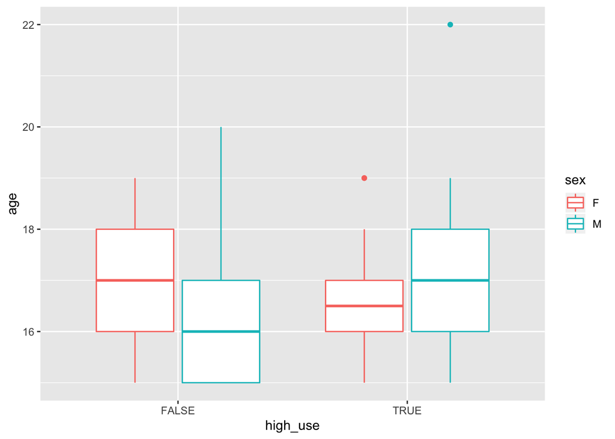

```r
g1 <- ggplot(alc, aes(x = high_use, y = age, col=sex))
g1 + geom_boxplot()
```

```r
alc %>% group_by(sex, high_use) %>% summarise(count = n())
```

```
## # A tibble: 4 x 3
## # Groups:   sex [2]
##   sex   high_use count
##   <fct> <lgl>    <int>
## 1 F     FALSE      156
## 2 F     TRUE        42
## 3 M     FALSE      112
## 4 M     TRUE        72
```

It seems that high alcohol use was more present in males. Males consuming more were older than low consuming males, whereas in females, the older consumed less alcohol

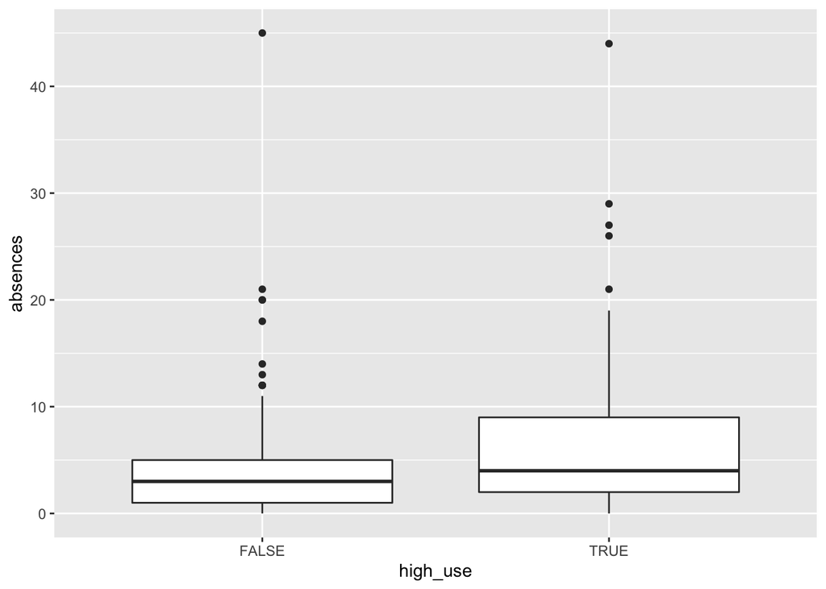

```r
g2 <- ggplot(alc, aes(x = high_use, y = absences))
g2 + geom_boxplot()
```

It seems that students in high use group have more absence from school than students than other students.

```r
alc %>% group_by(high_use) %>% summarise(count = n(), School_absence=mean(absences))
```

```
## # A tibble: 2 x 3
##   high_use count School_absence
##   <lgl>    <int>          <dbl>
## 1 FALSE      268           3.71
## 2 TRUE       114           6.37
```

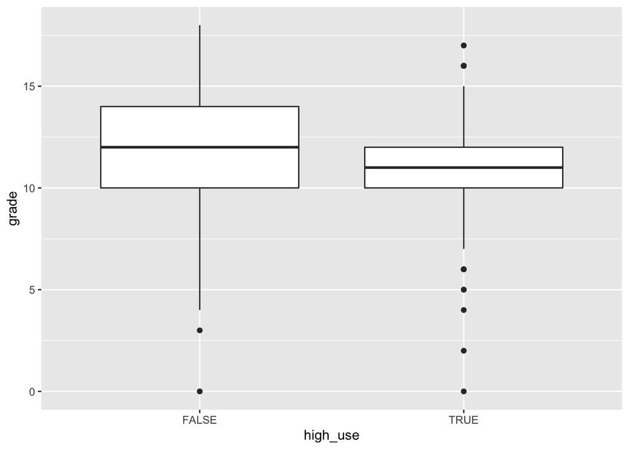

```r
g3 <- ggplot(alc, aes(x = high_use, y = G3))
g3 + geom_boxplot() + ylab("grade")
```

```r
alc %>% group_by(high_use) %>% summarise(count = n(), mean_grade = mean(G3))
```

```
## # A tibble: 2 x 3
##   high_use count mean_grade
##   <lgl>    <int>      <dbl>
## 1 FALSE      268       11.7
## 2 TRUE       114       10.8
```

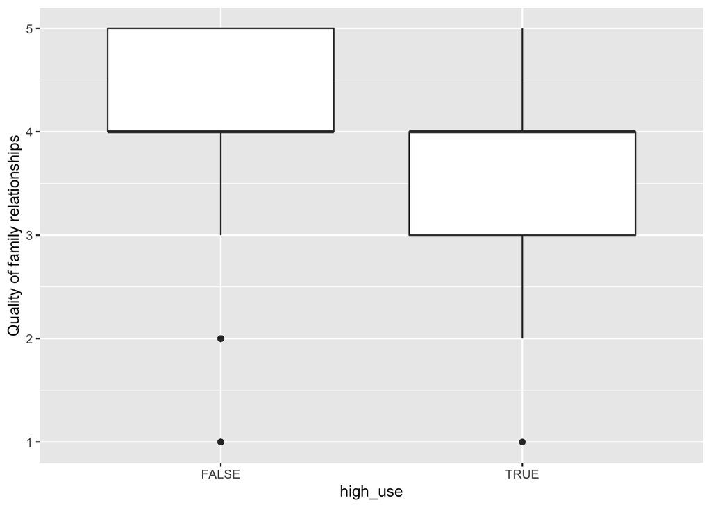

```r
g4 <- ggplot(alc, aes(x = high_use, y = famrel))
g4 + geom_boxplot() + ylab("Quality of family relationships")
```

```r
alc %>% group_by(high_use) %>% summarise(count = n(), Family_relationships = mean(famrel))
```

```
## # A tibble: 2 x 3
##   high_use count Family_relationships
##   <lgl>    <int>                <dbl>
## 1 FALSE      268                 4.00
## 2 TRUE       114                 3.78
```

```r
m <- glm(high_use ~ age + absences + famrel+G3, data = alc, family = "binomial")
print(m)
```

```
##
## Call:  glm(formula = high_use ~ age + absences + famrel + G3, family = "binomial",
##     data = alc)
##
## Coefficients:
## (Intercept)          age     absences       famrel           G3
##    -2.06975      0.14944      0.07981     -0.24448     -0.06241
##
## Degrees of Freedom: 381 Total (i.e. Null);  377 Residual
## Null Deviance:       465.7
## Residual Deviance: 437.2     AIC: 447.2
```

To see the coefficients of factor type variables directly, without an intercept, I have fitter the model by adding - 1 to the model formula. Following also coefficients of the model

```r
m1 <- glm(high_use ~ age + absences + sex-1 + famrel + G3, data = alc, family = "binomial")
coef(m1)
```

```
##         age    absences        sexF        sexM      famrel          G3
##  0.15270276  0.08669679 -2.53225653 -1.49900250 -0.29051313 -0.06176356
```

To calculate odds ratios and their confidence intervals, and print them out

```r
OR <- coef(m1) %>% exp
CI<-confint(m1)%>%exp
cbind(OR, CI)
```

```
##                  OR      2.5 %    97.5 %
## age      1.16497865 0.95043571 1.4323988
## absences 1.09056596 1.04507712 1.1426466
## sexF     0.07947947 0.00185329 3.2525841
## sexM     0.22335284 0.00528570 9.2331481
## famrel   0.74787971 0.58049882 0.9616909
## G3       0.94010513 0.87449700 1.0095533
```

To predict high_use, let’s first build a model with only the two significant factors absences and family relationships

```r
m7 <- glm(high_use ~ absences + famrel, data = alc, family = "binomial")
print(m7)
```

```
##
## Call:  glm(formula = high_use ~ absences + famrel, family = "binomial",
##     data = alc)
##
## Coefficients:
## (Intercept)     absences       famrel
##    -0.33027      0.08668     -0.24109
##
## Degrees of Freedom: 381 Total (i.e. Null);  379 Residual
## Null Deviance:       465.7
## Residual Deviance: 443.7     AIC: 449.7
```

Then we will predict the probability of high alcohol use, and add the predictive variable into the data. FInally, see the last ten classes and predicted probabilities, as well as class prediction:

```r
probabilities <- predict(m7, type = "response")
alc <- mutate(alc, probability = probabilities)
alc <- mutate(alc, prediction = probability > 0.5)
select(alc, absences,  high_use, famrel, probability, prediction) %>% tail(10)
```

```
##     absences high_use famrel probability prediction
## 373        0    FALSE      4   0.2150733      FALSE
## 374        7     TRUE      5   0.2831342      FALSE
## 375        1    FALSE      5   0.1901522      FALSE
## 376        6    FALSE      4   0.3154941      FALSE
## 377        2    FALSE      5   0.2038593      FALSE
## 378        2    FALSE      4   0.2457776      FALSE
## 379        2    FALSE      2   0.3454525      FALSE
## 380        3    FALSE      1   0.4227907      FALSE
## 381        4     TRUE      2   0.3856256      FALSE
## 382        2     TRUE      4   0.2457776      FALSE
```

Table regarding actual vs predicted values:

```r
table(high_use = alc$high_use, prediction = alc$prediction)
```

```
##         prediction
## high_use FALSE TRUE
##    FALSE   259    9
##    TRUE    101   13
```

Let’s draw a picture showing the actual and predicted values

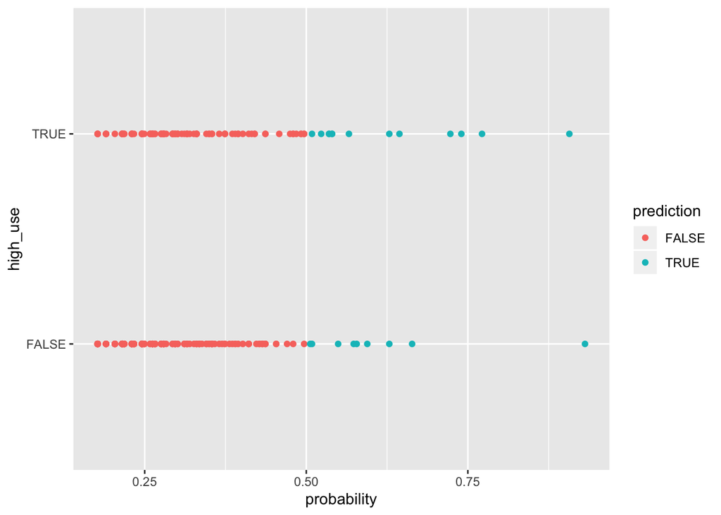

```r
g <- ggplot(alc, aes(x = probability, y = high_use, col = prediction))
g + geom_point()
```

Let us estimate the average number of wrong predictions (training error):

```r
loss_func <- function(class, prob) {
 n_wrong <- abs(class - prob) > 0.5
mean(n_wrong)
}
loss_func(class = alc$high_use, prob = alc$probability)
```

```
## [1] 0.2879581
```

##Bonus:A ten-fold cross-validation of the model, using functions in boot-library:

```r
library(boot)
cv <- cv.glm(data = alc, cost = loss_func, glmfit = m7, K = 10)
cv$delta[1]
```

```
## [1] 0.2827225
```

The error is 0.29, which is larger than the 0.26 error in DataCamp exercises. Thus, this model is not as good as in the examples. The smaller number of variables in this model might contribute to the larger error.

##Super-bonus: comparing the prediction error of a model with several variables to a model with less variables. Let’s choose the following variables to the first model: age, sex, no of past class failures, absences, famrel, studytime, final grades (G3).

```r
m2 <- glm(high_use ~ age + sex + failures + absences + famrel + studytime+ G3, data = alc, family = "binomial")
coef(m2)
```

```
## (Intercept)         age        sexM    failures    absences      famrel
## -1.99651236  0.14192390  0.86573372  0.21947105  0.08060070 -0.27823424
##   studytime          G3
## -0.32641486 -0.03484995
```

Testing the model against predicted

```r
probabilities <- predict(m2, type = "response")
alc <- mutate(alc, probability = probabilities)
alc <- mutate(alc, prediction = probability > 0.5)
loss_func <- function(class, prob) {
 n_wrong <- abs(class - prob) > 0.5
mean(n_wrong)
}
loss_func(class = alc$high_use, prob = alc$probability)
```

```
## [1] 0.2591623
```

```r
cv <- cv.glm(data = alc, cost = loss_func, glmfit = m2, K = 10)
cv$delta[1]
```

```
## [1] 0.2696335
```

Next let us create a model (m3)with less variables: age, sex, no of past class failures, absences, final grades (G3).

```r
m3 <- glm(high_use ~ age + sex + failures + absences + G3, data = alc, family = "binomial")
coef(m3)
```

```
## (Intercept)         age        sexM    failures    absences          G3
## -3.36159261  0.12110210  0.95711056  0.31893668  0.08900606 -0.04528170
```

The training errors of model m3:

```r
probabilities <- predict(m3, type = "response")
alc <- mutate(alc, probability = probabilities)
alc <- mutate(alc, prediction = probability > 0.5)
loss_func <- function(class, prob) {
 n_wrong <- abs(class - prob) > 0.5
mean(n_wrong)
}
loss_func(class = alc$high_use, prob = alc$probability)
```

```
## [1] 0.2513089
```

Testing error for m3:

```r
cv <- cv.glm(data = alc, cost = loss_func, glmfit = m3, K = 10)
cv$delta[1]
```

```
## [1] 0.2539267
```